# Hyne Log Metrics

### 3.1.3 Trimmed v Untrimmed

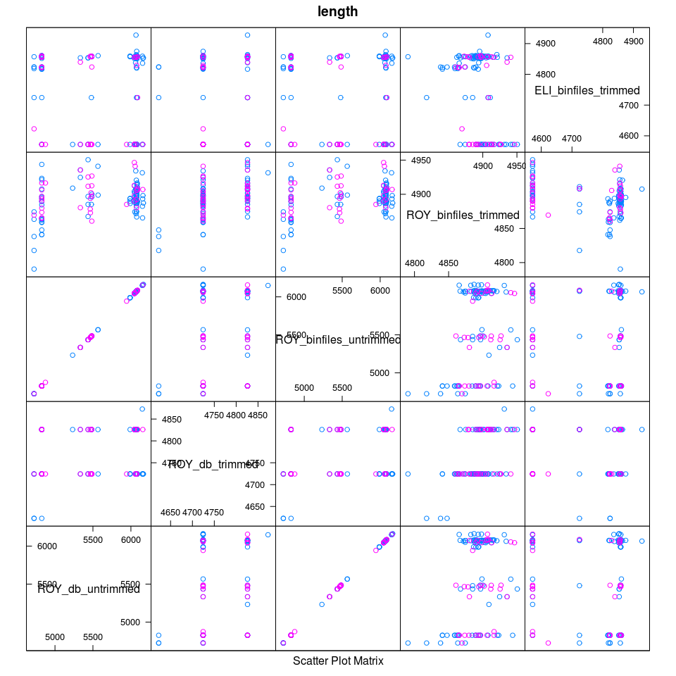

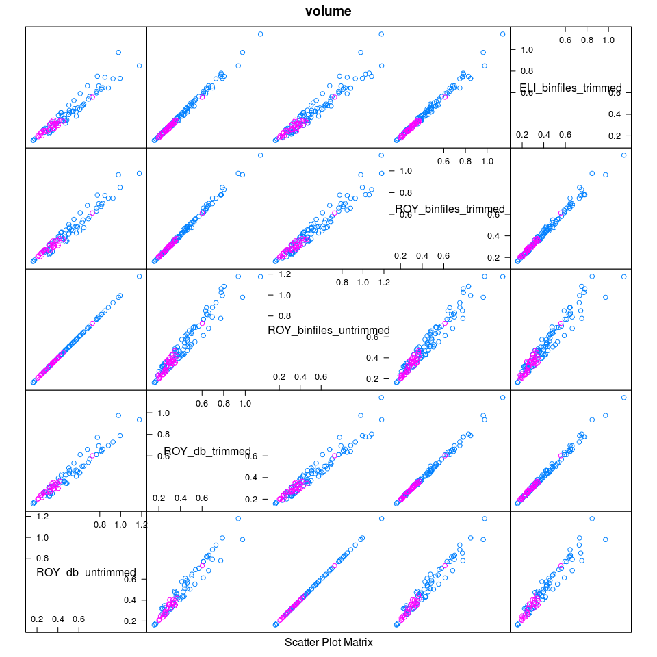

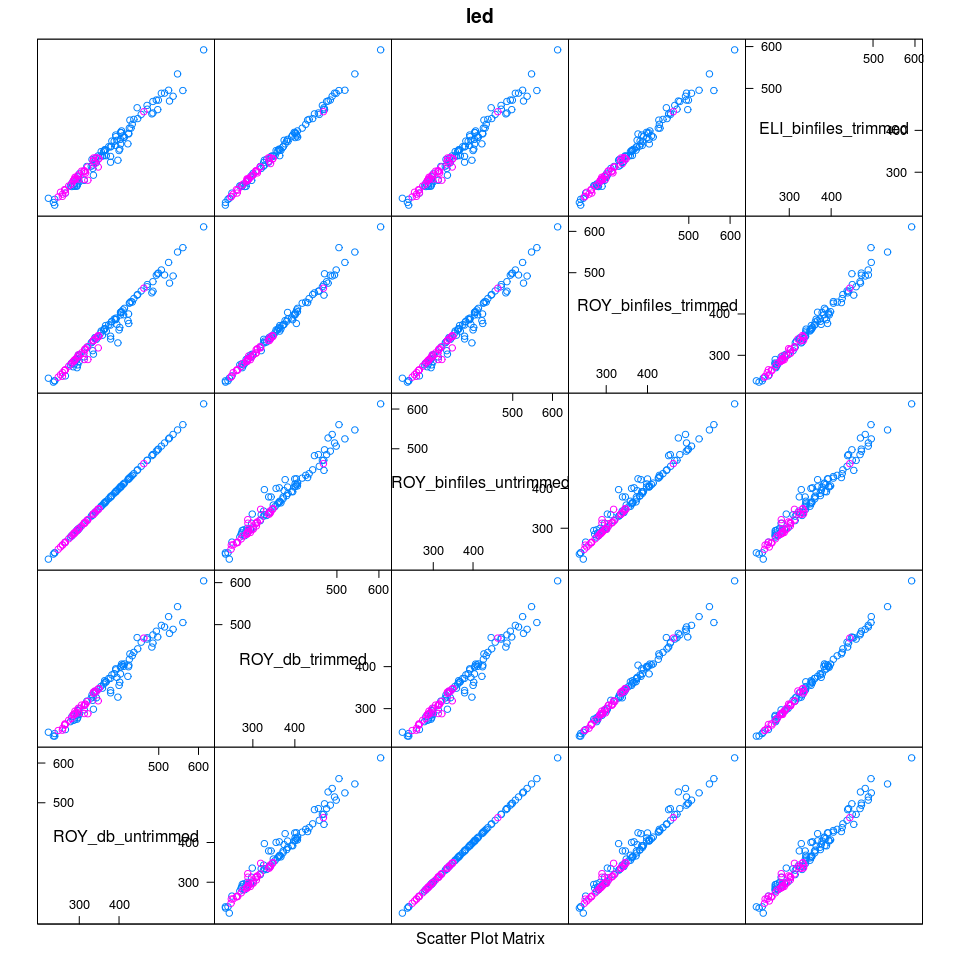

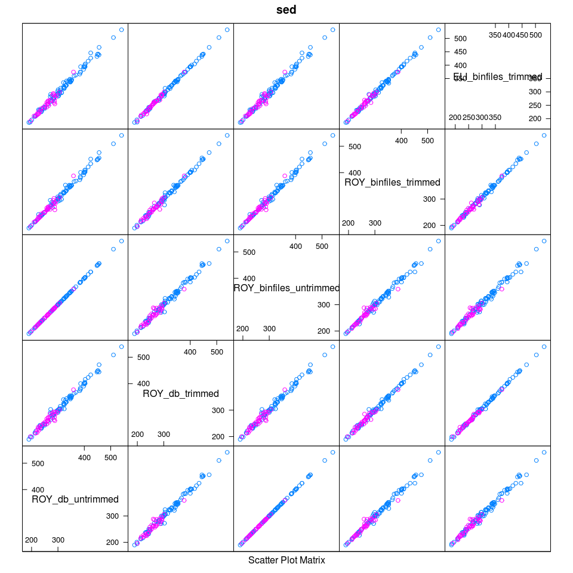

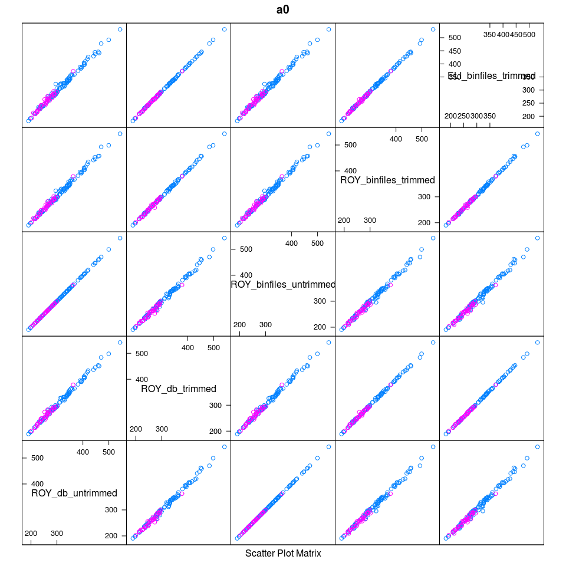

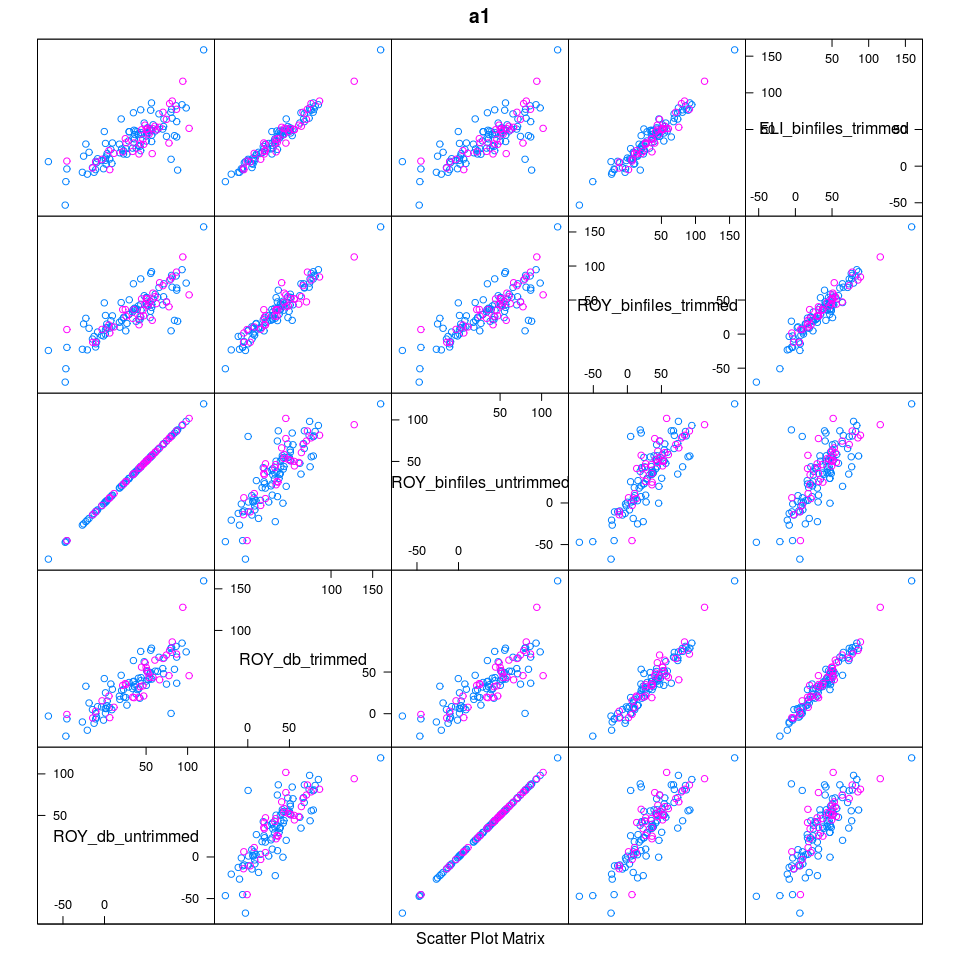

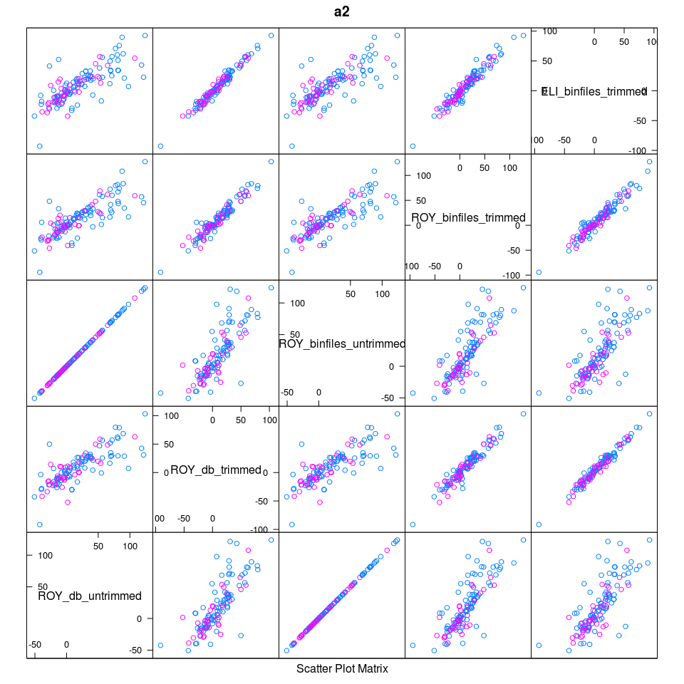

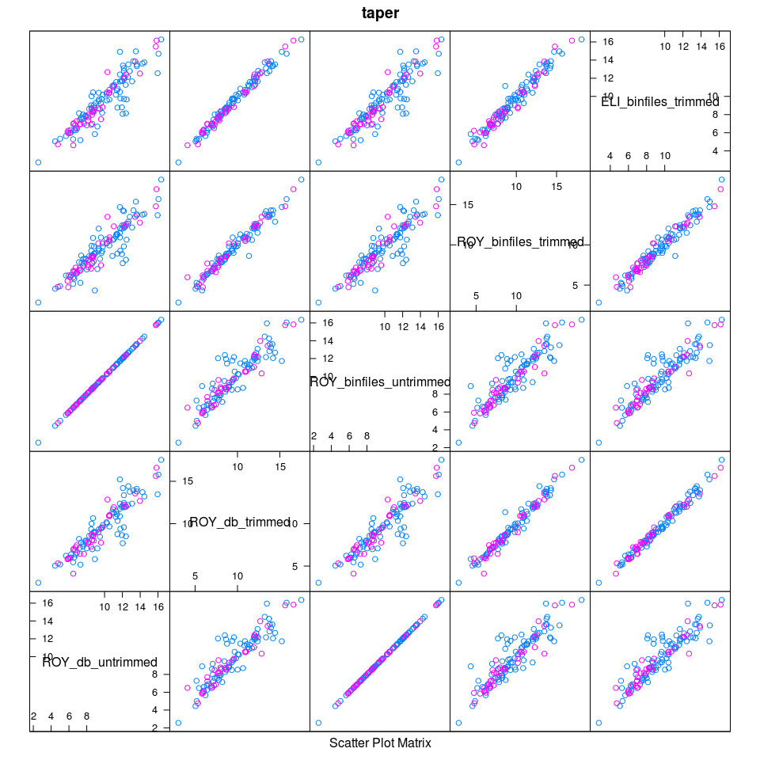

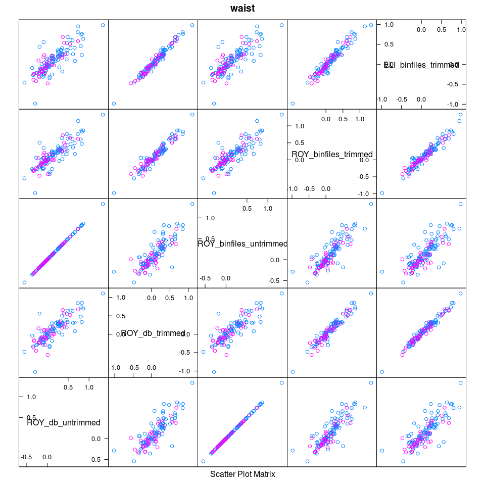

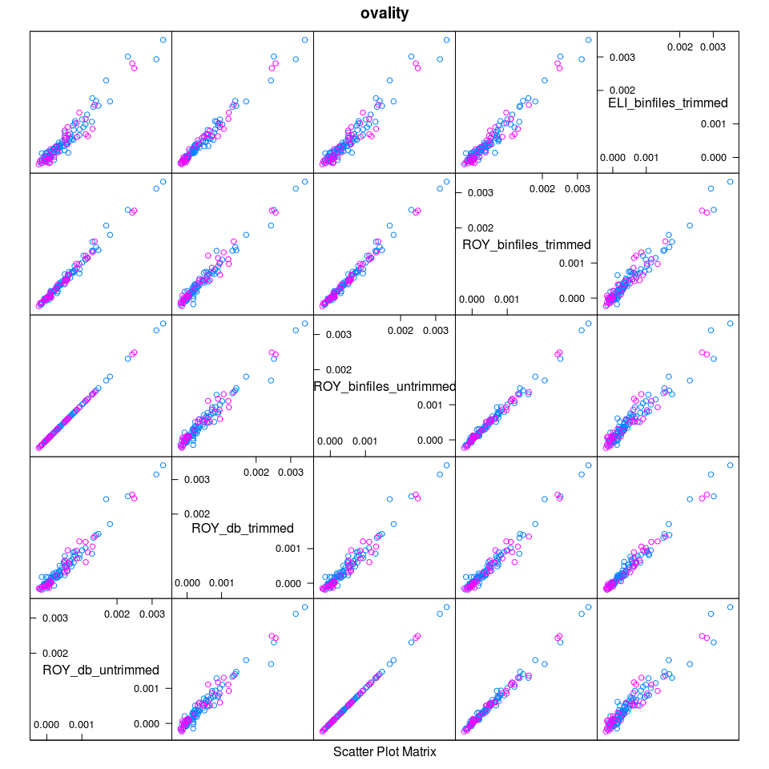

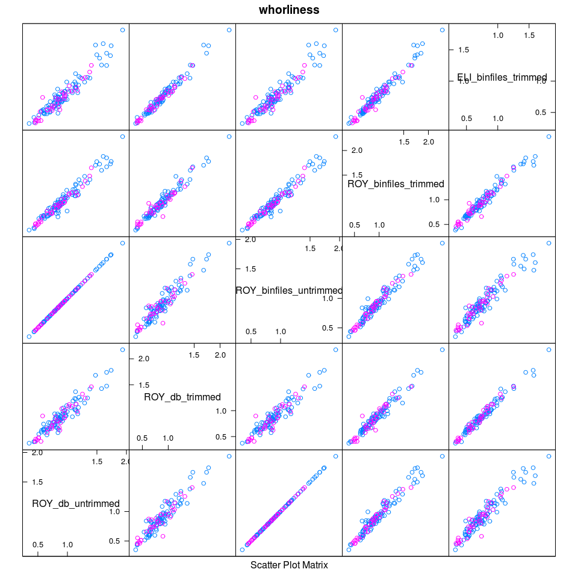

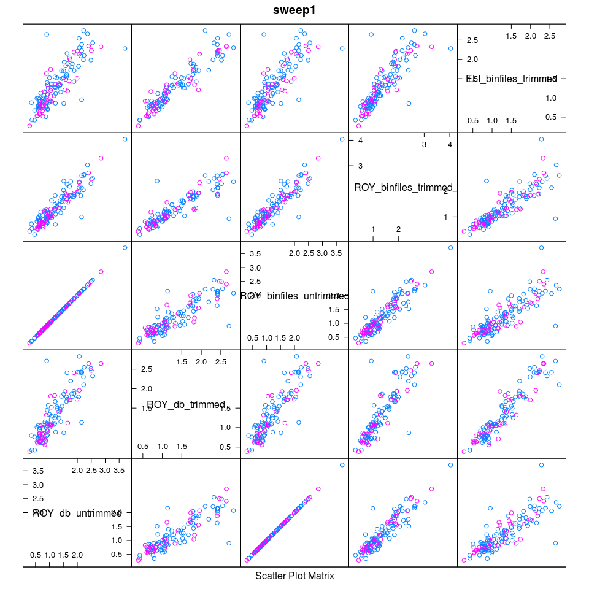

[7 more figures not shown]

```r
myplot = function(prop) {
  LL = dcast(L[!is.na(L[,prop]),], 'SWILogNumber ~ scanner + source + trimstate', mean, value.var=prop)
  try(print(splom(LL[,2:ncol(LL)], group=LL$SWILogNumber%in%flipped, main=prop)), silent=FALSE)
  return(LL)
}
for (p in log.metrics) {try(LL<-myplot(p), silent=FALSE)}
```

# 4 Xsectns

Plot all the xsectn data, sorted by some log metric.

```r
X = read.csv('/home/harrinjj/G/Projects/Hyne/USNR/xsectns.csv')
X = X[order(X$DistanceFromLE),]
re = "(?:.*USNR Image Files/)([^/]+)/(?:tri_cam)?(.+)\\.bin"
X$scanner = gsub(re,"\\1",X$binfn,perl=TRUE)
X$bindir = X$scanner
X$seq = as.numeric(gsub(re,"\\2",X$binfn,perl=TRUE))
# deal with the 8 non-trial logs that were on the deck
ii = X$scanner%in%c('HSS','ELI')
X$seq[ii] = X$seq[ii] - 8
#ii=X$scanner%in%c('ORI','ELI','HSS')&X$seq>0
ii=X$scanner%in%c('ELI','HSS')&X$seq>0
X$SWILogNumber[ii] = swi.log.numbers.in.sawing.order[X$seq[ii]]
for (ID in unique(X$seq[X$seq>500])) {
  if (!is.na(HH[ID])) {
    X$SWILogNumber[X$seq==ID] = HH[ID]
    }
}
# shorten the binfn
X$binfn = gsub('/media/Q/SWI/LogsAndStems/Hyne_2014/Aug2014/USNR Image Files/','',X$binfn)
# drop HSS binfiles - these are CANTS not logs
X = X[X$scanner%in%c('ELI'),]
# drop the first 8 logs...not part of trial
X = X[X$seq>0,]
```

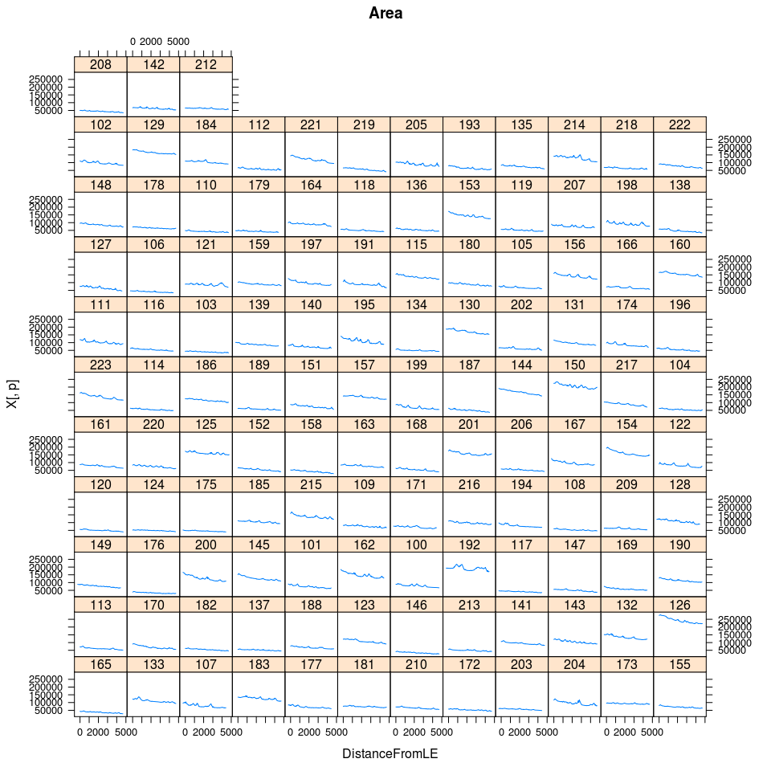

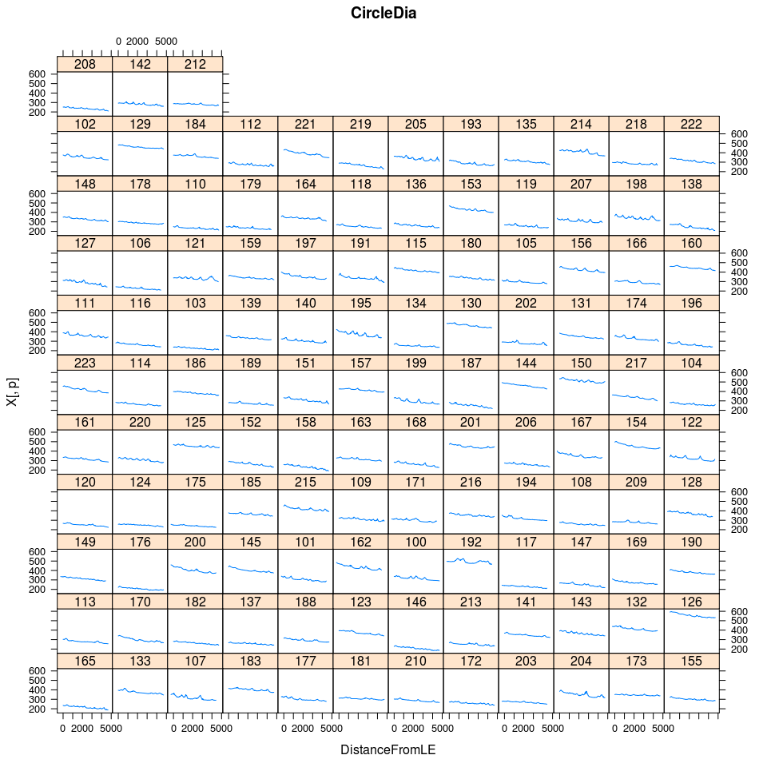

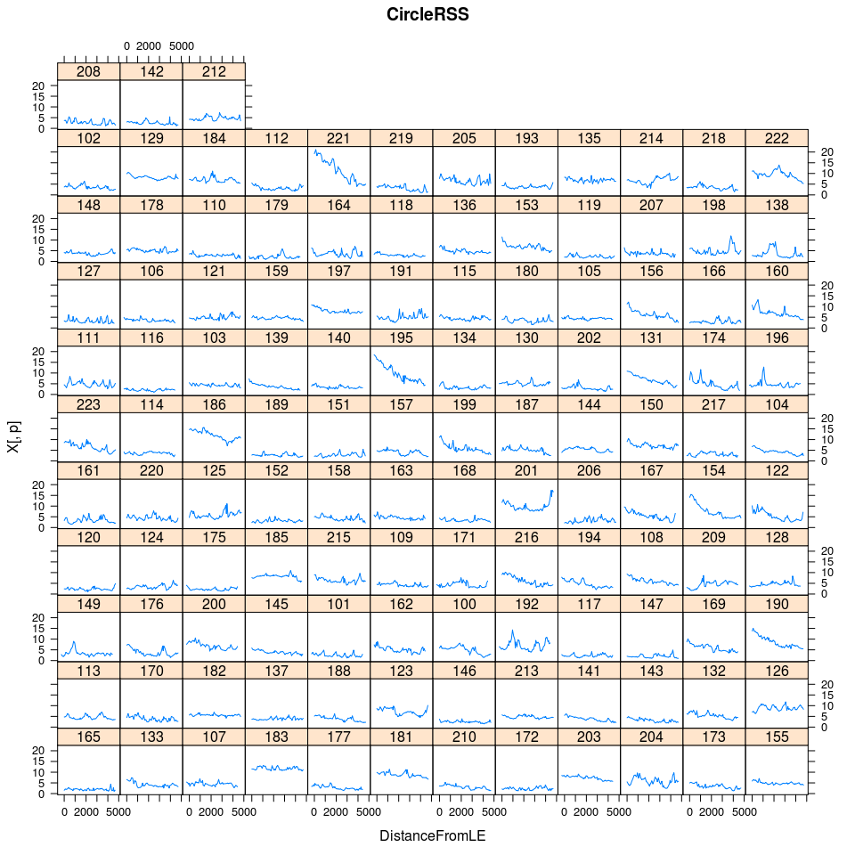

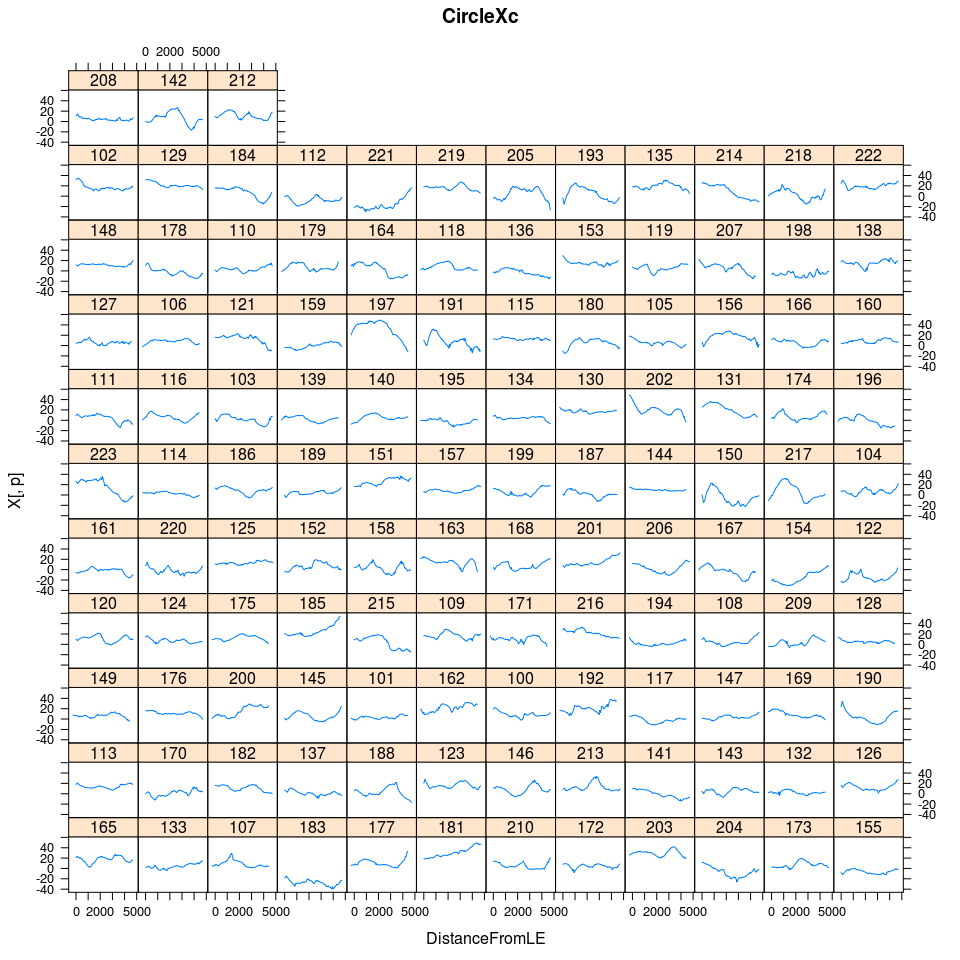

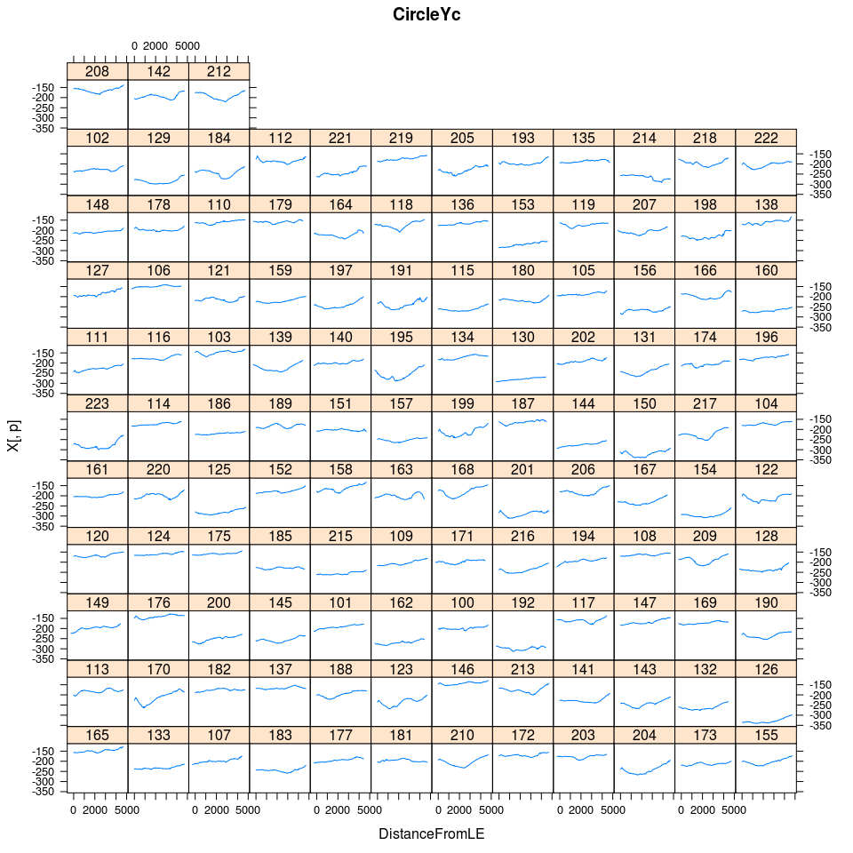

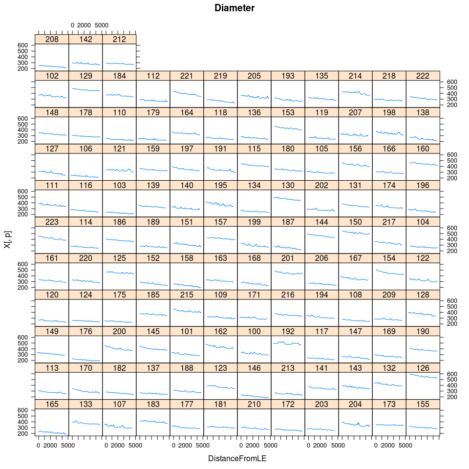

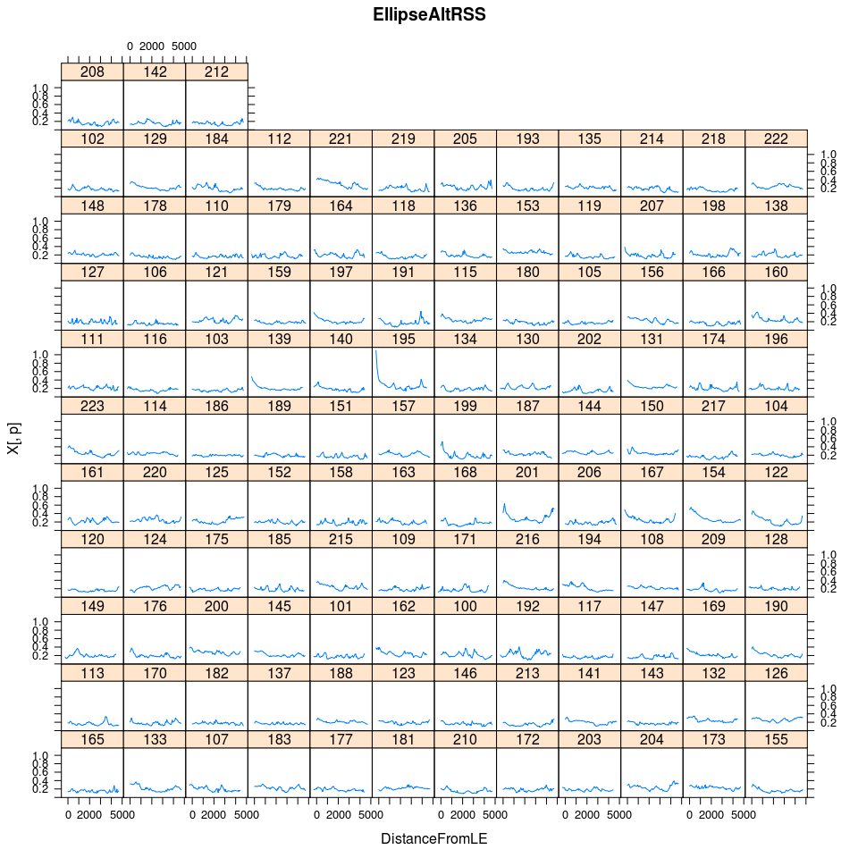

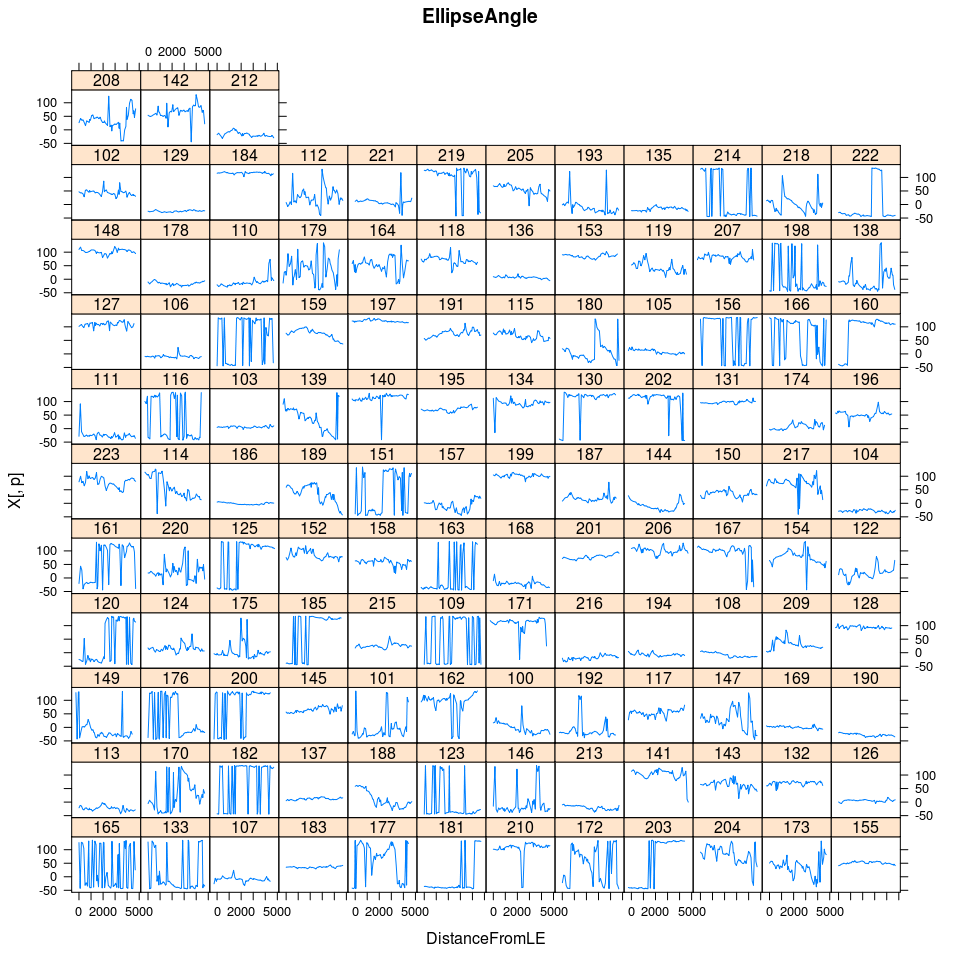

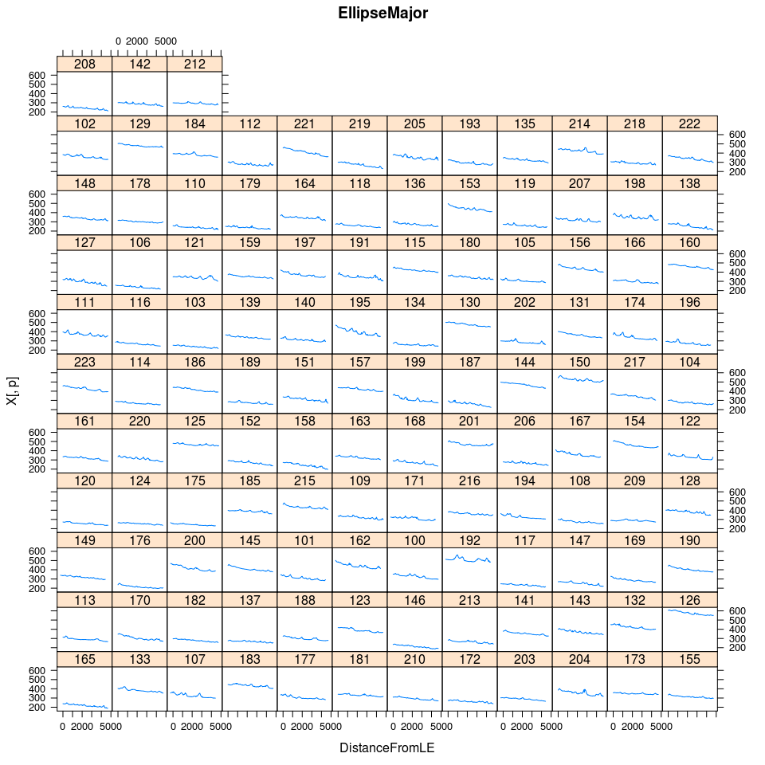

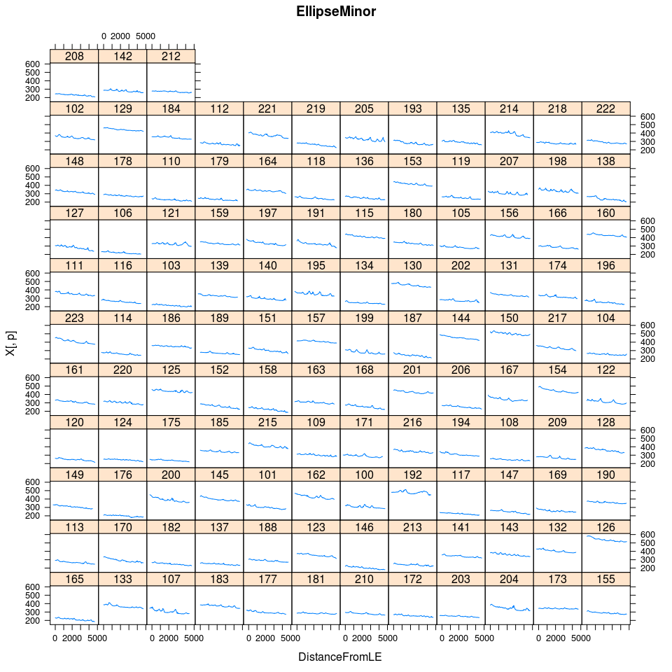

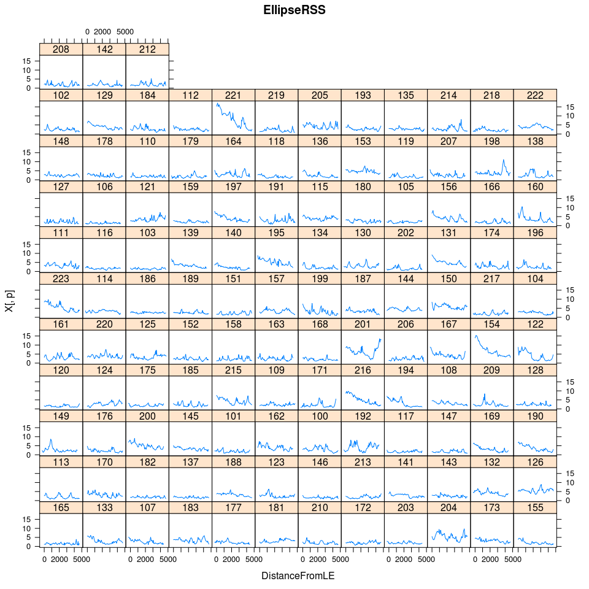

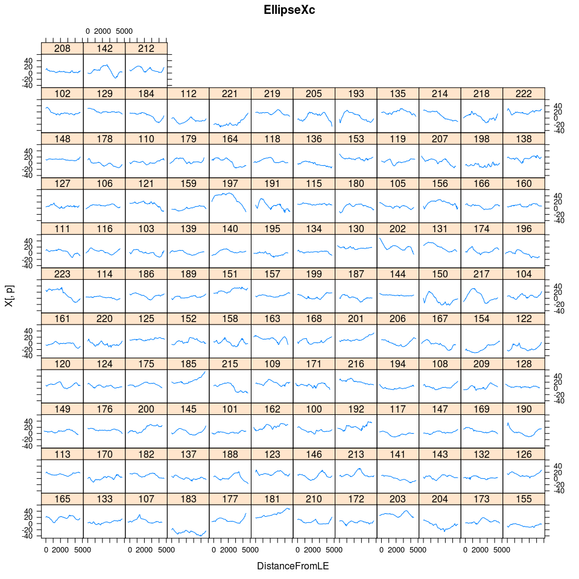

[4 more figures not shown]

```r
LL = sqlQuery(ch, 'select * from tmp_logquality')
X$SWILogNumber = factor(X$SWILogNumber, levels=LL$SWILogNumber[order(LL$crook_avg)], ordered=TRUE)
for (p in setdiff(names(X),c('binfn','trimstate','DistanceFromLE','scanner','seq','SWILogNumber','bindir'))) {
  print(xyplot(X[,p] ~ DistanceFromLE | SWILogNumber, X, main=p, type="l"
              #.strip=TRUE, subset=X$binfn%in%sample(binfns,100), layout=c(10,10,1)
              ))
}
```

# 5 Conclusions

Perhaps our selection strategy (looking for wide ranges in things like ovality) have inadvertently led to un-robust shapes. E.g. a log with a flapping broken bit looks weird to the scanner and appears ‘interesting’ to the selection software.

# 6 Todo

- take a good look at a catalog of log shapes
- in prediction models try using log metrics recomputed from binfiles from: DONE
- selection phase ROY scanner
- sawing phase ELI scanner

# 7 Appendix - Log Metric Dataset

```r
if (!require("DT")) devtools::install_github("rstudio/DT")
#datatable(data, options = list(), class = "display", callback = JS("return table;"), rownames, colnames, container, caption = NULL, filter = c("none", "bottom", "top"), server = FALSE, escape = TRUE, style = "default", extensions = list())
datatable(L)
```

|  | SWILogNumber | scanner | trimstate | source | seq | fail | origOrient | nslices | dzmax | dzmin | length | volume | led | sed | a0 | a1 | a2 | taper | waist | ovality | whorliness | sweep1 | sweep2 | binfn | gaxis_maxdev | gaxis_volume | sd_xsectnarea_butthalf | wobble | wobble_x | … |
| --- | --- | --- | --- | --- | --- | --- | --- | --- | --- | --- | --- | --- | --- | --- | --- | --- | --- | --- | --- | --- | --- | --- | --- | --- | --- | --- | --- | --- | --- | --- |
| 1 | 120 | ROY | untrimmed | db | 83751 |  | SE first | 59 | 129.802154541 | 101.6 | 6073.40215454 |  | 277.759470185 | 236.828780564 | 236.181811963 | 55.414692702 | -12.0985824941 | 7.1320997862 | -0.0819993519967 | 0.000208309141857 | 0.681817076776 | 1.51480031098 | 0.118670340531 |  |  |  |  |  |  | … |
| 2 | 117 | ROY | untrimmed | db | 83752 |  | LE first | 47 | 101.6 | 101.6 | 4826 |  | 247.012779586 | 220.609249217 | 215.43563115 | 50.0672253776 | -18.5035446573 | 6.54033997521 | -0.198618778254 | 6.21487992796e-05 | 0.509452507446 | 1.74473010714 | 0.175176425266 |  |  |  |  |  |  | … |
| 3 | 118 | ROY | untrimmed | db | 83754 |  | SE first | 59 | 133.908105469 | 101.6 | 6077.50810547 |  | 294.316052437 | 229.990899497 | 234.997612172 | 50.3309706675 | -2.34415462389 | 7.8958045322 | -0.0158662820454 | -0.000142800842046 | 0.773480571541 | 0.902869972974 | 0.218160463185 |  |  |  |  |  |  | … |
| 4 | 119 | ROY | untrimmed | db | 83755 |  | SE first | 59 | 129.802154541 | 101.6 | 6073.40215454 |  | 284.618645403 | 250.116307972 | 241.453349469 | 43.9083629758 | 3.82012713977 | 7.85860855269 | 0.0258912934765 | 1.90509593632e-05 | 0.953278037861 | 1.06221164983 | 0.151268186977 |  |  |  |  |  |  | … |
| 5 | 116 | ROY | untrimmed | db | 83757 |  | SE first | 60 | 109.63671875 | 101.6 | 6154.83671875 |  | 295.344750124 | 243.077152988 | 241.957624746 | 74.5823154827 | -20.4583199887 | 8.79373376862 | -0.1350134092 | -0.00017496759014 | 0.556967546995 | 0.55171639027 | 0.218253552194 |  |  |  |  |  |  | … |
| 6 | 115 | ROY | untrimmed | db | 83759 |  | SE first | 60 | 106.899676514 | 101.6 | 6152.09967651 |  | 485.313520503 | 402.980370735 | 406.393263618 | 2.70644598612 | 69.6996209164 | 11.7693260366 | 0.460387685038 | 8.99573563905e-05 | 0.590770785586 | 1.16783448713 | 0.154499580205 |  |  |  |  |  |  | … |
| 7 | 114 | ROY | untrimmed | db | 83760 |  | LE first | 60 | 111.689694214 | 101.6 | 6156.88969421 |  | 321.571448168 | 265.315299456 | 257.863815015 | 5.30355181811 | 53.7989548006 | 9.59940969452 | 0.354806119071 | 0.000576599084094 | 0.660100724115 | 0.661980999964 | 0.0877376637664 |  |  |  |  |  |  | … |
| 8 | 113 | ROY | untrimmed | db | 83761 |  | LE first | 59 | 131.170675659 | 101.6 | 6074.77067566 |  | 311.478424809 | 261.742099426 | 265.034710856 | 33.9082105458 | 19.4610243348 | 8.78539087812 | 0.131839615784 | 0.000512950572528 | 0.799014528462 | 0.73800266063 | 0.210682326093 |  |  |  |  |  |  | … |
| 9 | 112 | ROY | untrimmed | db | 83763 |  | SE first | 58 | 147.914227295 | 101.6 | 5989.91422729 |  | 335.615052908 | 273.262967382 | 268.941800416 | -14.5196239433 | 69.5866046445 | 9.19328367847 | 0.484869032922 | 0.000116332286422 | 0.83438274613 | 1.76438604439 | 0.258214283932 |  |  |  |  |  |  | … |
| 10 | 111 | ROY | untrimmed | db | 83764 |  | SE first | 60 | 108.268197632 | 101.6 | 6153.46819763 |  | 391.667621025 | 351.097234509 | 345.836181637 | 42.5480558969 | 16.8840366449 | 9.65830823091 | 0.111474715826 | 0.000312296966691 | 1.19469152821 | 0.924431433602 | 0.234304780033 |  |  |  |  |  |  | … |

[output cut: 607 more lines]